# 213-Discussion I

Yu-Shiuan (Lily) Huang

Apr 12, 2023

### Problem Set I

1. LaTex
2. R Markdown

### 1. LaTex

LaTeX is a high-quality typesetting system; it includes features designed for the production of technical and scientific documentation. LaTeX is the de facto standard for the communication and publication of scientific documents.

- Installation: [LaTeX installation guide](https://projects.iq.harvard.edu/files/gov2001/files/r_and_latex_installation.pdf)
- Short Tutorials: [LaTeX tutorial from Gov department PreFresher](https://projects.iq.harvard.edu/prefresher/additional-latex-resources)

If you prefer not to download the LaTeX compiler and editor to your laptop, you can use [Overleaf](https://www.overleaf.com/), which is an online LaTeX editor that is very easy to use and work on projects with multiple collaborators. It also provides many templates for you to choose from. Here is a brief [introduction video](https://www.youtube.com/watch?v=xcTN4F3l9Ds) of how to use Overleaf.

- To create a nice table output in Overleaf, [TablesGenerator](https://www.tablesgenerator.com/) is very helpful. You can also use `stargazer` in R to create regression tables in LaTeX form and copy them into Overleaf. Here is a [handout](https://ignacioriveros1.github.io/r/2021/03/25/stargazer-for-amazing-academic-tables.html) of how to use the `stargazer` package.
- To insert math equations in Overleaf, [LaTeX Equation Editor](https://latex.codecogs.com/eqneditor/editor.php) would be your go-to.

Here is an [Overleaf template](https://www.overleaf.com/read/xsjrvdctfjjz) for POL 213 Problem Set I. Please feel free to copy it to your future work!

### 2. R Markdown

Another way to submit both your answers and R code with only one pdf document is by using *R Markdown*.

R Markdown is a markup language that allows you to create dynamic documents in R programming language. With R Markdown, you can easily combine text, code, and visualizations in a single document. R Markdown documents can be rendered in a variety of output formats, including HTML, PDF, Microsoft Word, and more.

R Markdown provides a way to weave together narrative text, code, and results into a single document that can be easily shared and reproduced. It allows you to write code and see the results of that code inline, making it easy to explain complex statistical analyses or data visualizations.

Here is a thorough introduction of [how to use R Markdown](https://rmarkdown.rstudio.com/lesson-1.html).

Let’s try writing down some answers for PS1 using R Markdown.

#### Question 1: Least Squares Fit

- response variable (y): *prestige*
- explanatory variable (x): *education*

###### b. regression coefficient B

$B=\frac{\Sigma(X_i-\bar{X})(Y_i-\bar{Y})}{\Sigma(X_i-\bar{X})^2}$

$B=[(86-88)*(82-83.1)+(76-88)*(83-83.1)+(92-88)*(90-83.1)+ $ $(90-88)*(76-83.1)+(86-88)*(90-83.1)+(84-88)*(87-83.1)+ $ $(93-88)*(93-83.1)+(100-88)*(90-83.1)+ (87-88)*(52-83.1)+ (86-88)*(88-83.1)]/$ $[(86-88)^2 +(76-88)^2 + (92-88)^2 + (90-88)^2 + (86-88)^2 + (84-88)^2 + \\(93-88)^2 + (100-88)^2 + (87-88)^2 + (86-88)^2] = 0.3895028$

Overall, the syntax for typing math equations in R Markdown and LaTeX is largely the same. Both use the same basic markup language for math expressions, called LaTeX markup. In fact, R Markdown uses a LaTeX engine behind the scenes to typeset math equations.

Instead of using a calculator to calculate the above tedious equation by hand, you can use R to perform calculations on complex equations to reduce the likelihood of calculation errors.

```r
# load data
df <- read.csv("data/ps1_prestige.csv")
# this data can be downloaded from Canvas
df
```

```
##    prestige education
## 1        82        86
## 2        83        76
## 3        90        92
## 4        76        90
## 5        90        86
## 6        87        84
## 7        93        93
## 8        90       100
## 9        52        87
## 10       88        86
```

```r
# calculate B
b <- sum((df$education-mean(df$education))*(df$prestige-mean(df$prestige)))/
    sum((df$education-mean(df$education))^2)
b
```

```
## [1] 0.3895028
```

###### a. intercept A

$A=\bar{Y}-B\bar{X}$

$A=83.1-0.3895028*88=48.82376$

```r
# calculate A
a <- mean(df$prestige)-b*mean(df$education)
a
```

```
## [1] 48.82376
```

Let’s double check our answers by running `lm()`.

```r
# simple regression
fit <- lm(prestige ~ education, data = df)
summary(fit)
```

```
##
## Call:
## lm(formula = prestige ~ education, data = df)
##
## Residuals:
##      Min       1Q   Median       3Q      Max
## -30.7105   0.3157   4.9580   5.6238   7.9525
##
## Coefficients:
##             Estimate Std. Error t value Pr(>|t|)
## (Intercept)  48.8238    57.8100   0.845    0.423
## education     0.3895     0.6554   0.594    0.569
##
## Residual standard error: 12.47 on 8 degrees of freedom
## Multiple R-squared:  0.04228,    Adjusted R-squared:  -0.07743
## F-statistic: 0.3532 on 1 and 8 DF,  p-value: 0.5687
```

Here are the formulas for the rest of the questions in Q1. Feel free to copy these syntax into your LaTex or R Markdown.

###### c. residual standard error $S_E$

$S_E = \sqrt{\frac{\Sigma {E_i}^2}{n-2}}$

###### d. total sum of squares (TSS)

$\Sigma {E'_i}^2=\Sigma (Y_i-\bar{Y})^2$

###### e. residual sum of squares (RSS)

$\Sigma {E_i}^2=\Sigma (Y_i-\hat{Y})^2$

###### f. regression sum of squares (RegSS)

$RegSS = TSS - RSS$

###### g. R-squared

$r^2 = \frac{RegSS}{TSS}$

#### Question 2: Single and Multivariate Regression

Here I provide an example of how R Markdown can also present graphs we generate through R.

##### a. Draw a separate scatterplot showing the relationship of the response variable *education* to each explanatory variable.

```r
# load data
df2 <- read.delim("data/Anscombe.txt", sep = "")
head(df2)
```

```
##    education income under18 urban
## ME       189   2824   350.7   508
## NH       169   3259   345.9   564
## VT       230   3072   348.5   322
## MA       168   3835   335.3   846
## RI       180   3549   327.1   871
## CT       193   4256   341.0   774
```

Let’s first draw a scatterplot between **education** and **income**.

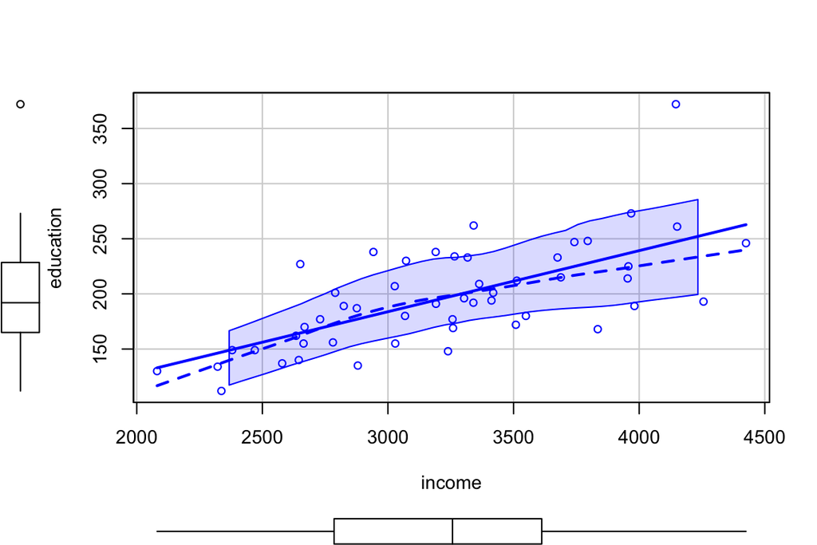

```r
library(car)
scatterplot(education ~ income, data = df2)
```

##### b. Compute the simple (bivariate) linear regression of the response on each explanatory variable. Once you have each bivariate regression, report the A, B, SE, and r and substantively interpret each of these quanties.

Here I provide an example of how to generate a nice output of a regression table using `stargazer` package.

```r
# regression output
m1 <- lm(education ~ income, data = df2)
m2 <- lm(education ~ under18, data = df2)
m3 <- lm(education ~ urban, data = df2)

library(stargazer)
stargazer(m1, m2, m3, type = "text", digits = 2)
```

```
##
## ===========================================================
##                                    Dependent variable:
##                               -----------------------------
##                                         education
##                                  (1)       (2)       (3)
## -----------------------------------------------------------
## income                         0.06***
##                                 (0.01)
##
## under18                                   0.60**
##                                           (0.26)
##
## urban                                               0.08*
##                                                    (0.04)
##
## Constant                        17.71     -20.42  142.60***
##                                (28.87)   (94.66)   (28.82)
##
## -----------------------------------------------------------
## Observations                      51        51       51
## R2                               0.45      0.10     0.07
## Adjusted R2                      0.43      0.08     0.05
## Residual Std. Error (df = 49)   34.94     44.59     45.27
## F Statistic (df = 1; 49)       39.39***   5.26**    3.65*
## ===========================================================
## Note:                           *p<0.1; **p<0.05; ***p<0.01
```

If you’d like to have the LaTex syntax of this table to be put into your LaTex, just remove the `type` argument. It will automatically generate the corresponding LaTex code.

```r
stargazer(m1, m2, m3, digits = 2)
```

```
##
## % Table created by stargazer v.5.2.3 by Marek Hlavac, Social Policy Institute. E-mail: marek.hlavac at gmail.com
## % Date and time: Fri, Sep 22, 2023 - 15:31:32
## \begin{table}[!htbp] \centering
##   \caption{}
##   \label{}
## \begin{tabular}{@{\extracolsep{5pt}}lccc}
## \\[-1.8ex]\hline
## \hline \\[-1.8ex]
##  & \multicolumn{3}{c}{\textit{Dependent variable:}} \\
## \cline{2-4}
## \\[-1.8ex] & \multicolumn{3}{c}{education} \\
## \\[-1.8ex] & (1) & (2) & (3)\\
## \hline \\[-1.8ex]
##  income & 0.06$^{***}$ &  &  \\
##   & (0.01) &  &  \\
##   & & & \\
##  under18 &  & 0.60$^{**}$ &  \\
##   &  & (0.26) &  \\
##   & & & \\
##  urban &  &  & 0.08$^{*}$ \\
##   &  &  & (0.04) \\
##   & & & \\
##  Constant & 17.71 & $-$20.42 & 142.60$^{***}$ \\
##   & (28.87) & (94.66) & (28.82) \\
##   & & & \\
## \hline \\[-1.8ex]
## Observations & 51 & 51 & 51 \\
## R$^{2}$ & 0.45 & 0.10 & 0.07 \\
## Adjusted R$^{2}$ & 0.43 & 0.08 & 0.05 \\
## Residual Std. Error (df = 49) & 34.94 & 44.59 & 45.27 \\
## F Statistic (df = 1; 49) & 39.39$^{***}$ & 5.26$^{**}$ & 3.65$^{*}$ \\
## \hline
## \hline \\[-1.8ex]
## \textit{Note:}  & \multicolumn{3}{r}{$^{*}$p$<$0.1; $^{**}$p$<$0.05; $^{***}$p$<$0.01} \\
## \end{tabular}
## \end{table}
```

Finally, if you’d like to submit a pdf of R Markdown, just hit the `Knit` button and render it to a pdf format. Note that if you would like to create PDF documents from R Markdown, you will need to have a LaTeX distribution installed. Otherwise, it will not work.